# L13Ex_ToolLifeEx_Rick_Davila

Rick Davila

5/29/2020

#### Perform data housekeeping - upload, name columns, display to make sure it reads properly, etc.

```r
knitr::opts_chunk$set(echo = TRUE)

Sys.setenv(JAVA_HOME='C:\\Program Files\\Java\\jdk-14.0.1') # for 64-bit version
library(rJava)
library(e1071)
library("xlsx")
library(xtable)
# for laptop 2 -- result of reloading java JDK version


rm(list = ls())

# load data
Ex81 <- read.xlsx(
  "data-ex-8-1.xlsx",
  sheetIndex = 1, sheetName=NULL, rowIndex=NULL,
  startRow=NULL, endRow=NULL, colIndex= c(1,2,3,4),
  as.data.frame=TRUE, header=TRUE, colClasses=NA,
  keepFormulas=FALSE, encoding="unknown")

# Give labels to data columns
names(Ex81) <- c("Obs",
                 "y_i",
                 "x_1",
                 "Tool_Type")
attach(Ex81)

# Output data to make sure it reads properly
out <- as.data.frame(c(Ex81))
colnames(out) <- c("Obs",
                 "y_i",
                 "x_1",
                 "Tool_Type")
tab <- (xtable(out, digits=c(0,0,2,0,0)))
print(tab, type="html")
```

|  | Obs | y_i | x_1 | Tool_Type |
| --- | --- | --- | --- | --- |
| 1 | 1 | 18.73 | 610 | A |
| 2 | 2 | 14.52 | 950 | A |
| 3 | 3 | 17.43 | 720 | A |
| 4 | 4 | 14.54 | 840 | A |
| 5 | 5 | 13.44 | 980 | A |
| 6 | 6 | 24.39 | 530 | A |
| 7 | 7 | 13.34 | 680 | A |
| 8 | 8 | 22.71 | 540 | A |
| 9 | 9 | 12.68 | 890 | A |
| 10 | 10 | 19.32 | 730 | A |
| 11 | 11 | 30.16 | 670 | B |
| 12 | 12 | 27.09 | 770 | B |
| 13 | 13 | 25.40 | 880 | B |
| 14 | 14 | 26.05 | 1000 | B |
| 15 | 15 | 33.49 | 760 | B |
| 16 | 16 | 35.62 | 590 | B |
| 17 | 17 | 26.07 | 910 | B |
| 18 | 18 | 36.78 | 650 | B |
| 19 | 19 | 34.95 | 810 | B |
| 20 | 20 | 43.67 | 500 | B |

```r
# Output data structure and dimensions
str(Ex81)
```

‘data.frame’: 20 obs. of 4 variables: $ Obs : num 1 2 3 4 5 6 7 8 9 10 … $ y_i : num 18.7 14.5 17.4 14.5 13.4 … $ x_1 : num 610 950 720 840 980 530 680 540 890 730 … $ Tool_Type: chr “A” “A” “A” “A” …

```r
dim(Ex81)
```

[1] 20 4

## Example 8.1 (p.262-264)

#### Create scatterplot to look at the data - all points look the same

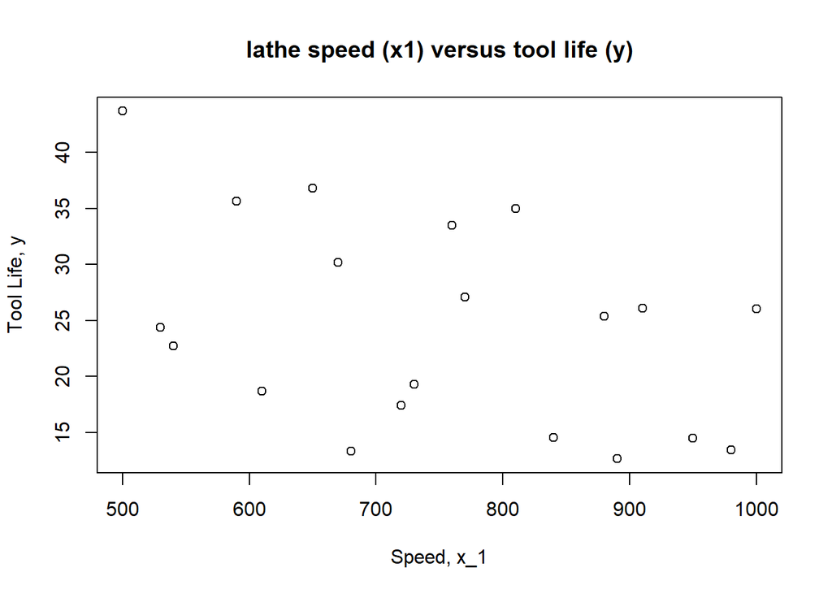

```r
plot(x_1,y_i, main = "lathe speed (x1) versus tool life (y)",
     xlab = "Speed, x_1",
     ylab = "Tool Life, y")
```

#### Create scatterplot - distinguish between Tool Type using points() command to make Tool Type A green and Tool Type B red.

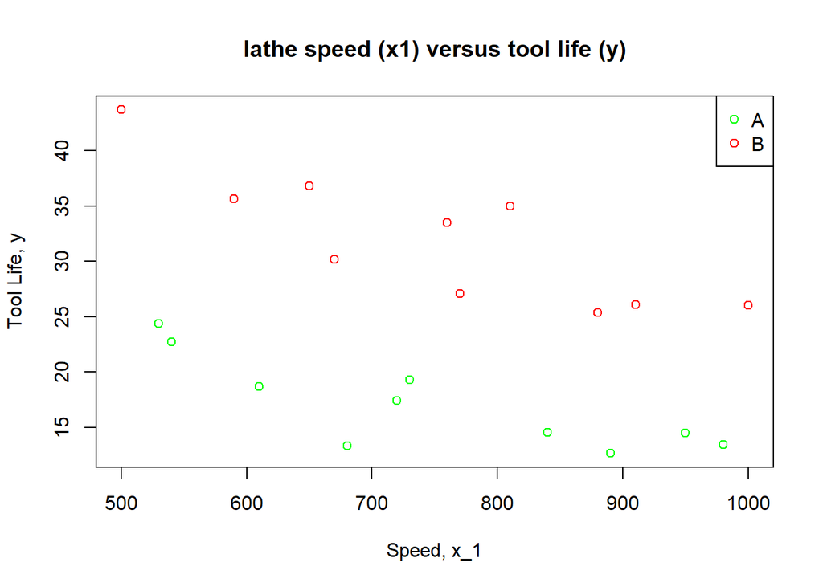

```r
plot(x_1,y_i, main = "lathe speed (x1) versus tool life (y)",
     xlab = "Speed, x_1",
     ylab = "Tool Life, y")

# in the for loop, use points() function to distinguish between tool types
for (pltpts in seq(1:length(y_i))){

  if (Tool_Type[pltpts] == "A") {
    points(x_1[pltpts], y_i[pltpts], col = "green")}
  else if (Tool_Type[pltpts] == "B") {
    points(x_1[pltpts], y_i[pltpts], col = "red")}
}

legend("topright", legend=c("A", "B"),
       col=c("green", "red"),
       pch=c(1,1))
```

#### Define indicator variables for Tool Type and add to dataframe

```r
x_2 <- vector()

for (i in seq(1:length(y_i))){

  if (Tool_Type[i] == "A") {
    x_2[i] = 1}
  else if (Tool_Type[i] == "B") {
    x_2[i] = 0}
}

Ex81$x_2 <- c(x_2)

# Output data to make sure it reads properly
out <- as.data.frame(c(Ex81))
colnames(out) <- c("Obs",
                 "y_i",
                 "x_1",
                 "Tool_Type",
                 "x_2")
tab <- (xtable(out, digits=c(0,0,2,0,0,0)))
print(tab, type="html")
```

|  | Obs | y_i | x_1 | Tool_Type | x_2 |
| --- | --- | --- | --- | --- | --- |
| 1 | 1 | 18.73 | 610 | A | 1 |
| 2 | 2 | 14.52 | 950 | A | 1 |
| 3 | 3 | 17.43 | 720 | A | 1 |
| 4 | 4 | 14.54 | 840 | A | 1 |
| 5 | 5 | 13.44 | 980 | A | 1 |
| 6 | 6 | 24.39 | 530 | A | 1 |
| 7 | 7 | 13.34 | 680 | A | 1 |
| 8 | 8 | 22.71 | 540 | A | 1 |
| 9 | 9 | 12.68 | 890 | A | 1 |
| 10 | 10 | 19.32 | 730 | A | 1 |
| 11 | 11 | 30.16 | 670 | B | 0 |
| 12 | 12 | 27.09 | 770 | B | 0 |
| 13 | 13 | 25.40 | 880 | B | 0 |
| 14 | 14 | 26.05 | 1000 | B | 0 |
| 15 | 15 | 33.49 | 760 | B | 0 |
| 16 | 16 | 35.62 | 590 | B | 0 |
| 17 | 17 | 26.07 | 910 | B | 0 |
| 18 | 18 | 36.78 | 650 | B | 0 |
| 19 | 19 | 34.95 | 810 | B | 0 |
| 20 | 20 | 43.67 | 500 | B | 0 |

#### Create linear model; compare to Table 8.2 on p. 264

```r
model.81 <- lm(y_i ~ x_1 + x_2)

print(xtable(summary(model.81),
             digits=c(0,3,3,2,3),
             display=c("s","f","f","f","g"))
      ,type="html")
```

|  | Estimate | Std. Error | t value | Pr(>\|t\|) |
| --- | --- | --- | --- | --- |
| (Intercept) | 51.990 | 3.541 | 14.68 | 4.34e-11 |
| x_1 | -0.027 | 0.005 | -5.89 | 1.79e-05 |
| x_2 | -15.004 | 1.360 | -11.04 | 3.59e-09 |

```r
print(xtable(anova(model.81),
             digits=c(0,0,3,3,3,3),
             display=c("s","d","f","f","f","g"))
      ,type="html")
```

|  | Df | Sum Sq | Mean Sq | F value | Pr(>F) |
| --- | --- | --- | --- | --- | --- |
| x_1 | 1 | 293.005 | 293.005 | 31.716 | 2.99e-05 |
| x_2 | 1 | 1125.028 | 1125.028 | 121.776 | 3.59e-09 |
| Residuals | 17 | 157.055 | 9.239 |  |  |

The least squares fit equation is:
$$\hat{y}= 51.9898518 +
(-0.0266072)x_1 +
(-15.0042506)x_2$$

$$R^2 = 0.9002884$$
$$R^2_{adj} = 0.8885576$$
$$F_0 = 76.7458491$$

#### Check model adequacy with residual plots

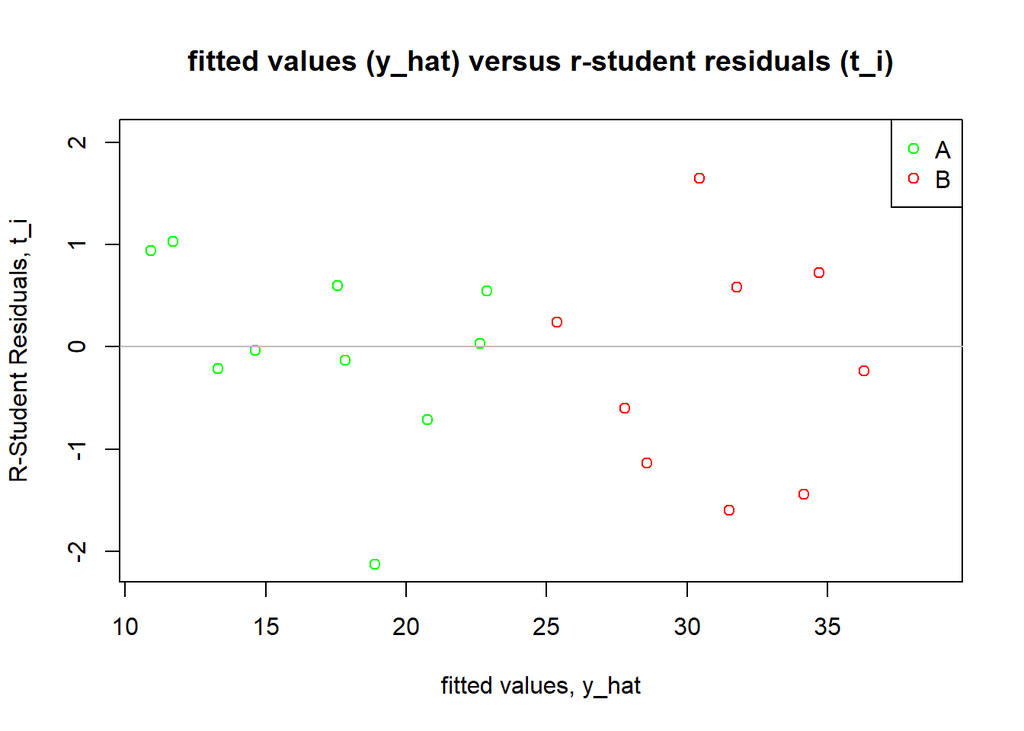

```r
# fitted values (y_hat) versus R-student residuals (t_i)
plot(model.81$fitted.values, rstudent(model.81),
     main = "fitted values (y_hat) versus r-student residuals (t_i)",
     xlab = "fitted values, y_hat",
     ylab = "R-Student Residuals, t_i")

for (pltpts in seq(1:length(y_i))){

  if (Tool_Type[pltpts] == "A") {
    points(model.81$fitted.values[pltpts],
           rstudent(model.81)[pltpts],
           col = "green")}
  else if (Tool_Type[pltpts] == "B") {
    points(model.81$fitted.values[pltpts],
           rstudent(model.81)[pltpts],
           col = "red")}
}

legend("topright", legend=c("A", "B"),
       col=c("green", "red"),
       pch=c(1,1))
abline(0,0,col="gray")
```

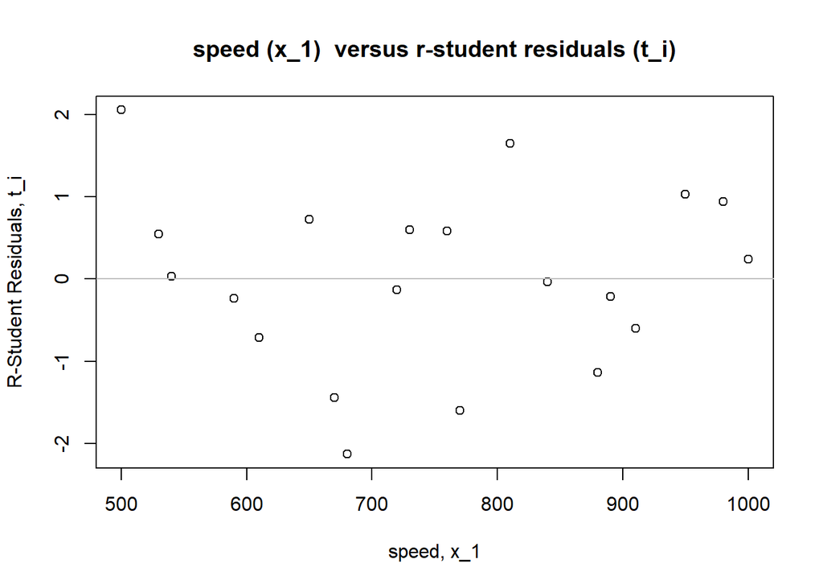

```r
# speed versus rstudent residuals
plot(x_1, rstudent(model.81),
     main = "speed (x_1)  versus r-student residuals (t_i)",
     xlab = "speed, x_1",
     ylab = "R-Student Residuals, t_i")
abline(0,0,col="gray")
```

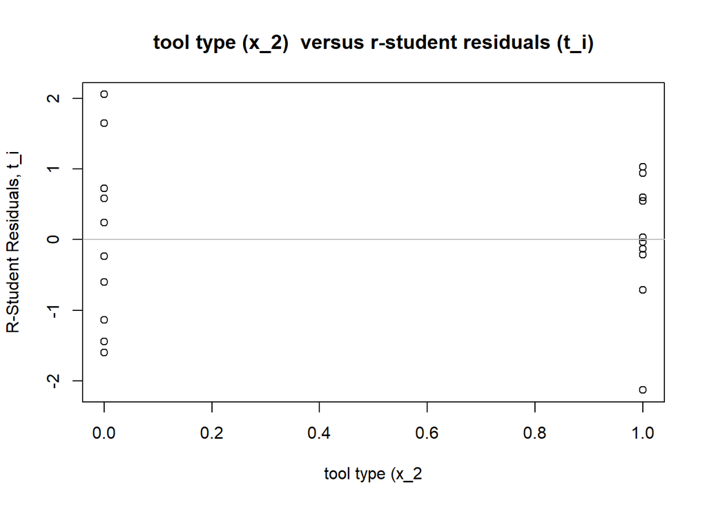

```r
# speed versus rstudent residuals
plot(x_2, rstudent(model.81),
     main = "tool type (x_2)  versus r-student residuals (t_i)",
     xlab = "tool type (x_2",
     ylab = "R-Student Residuals, t_i")
abline(0,0,col="gray")
```

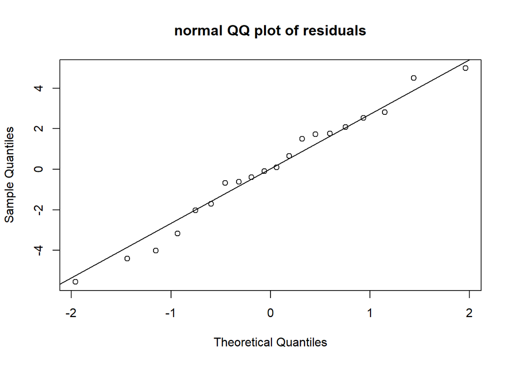

```r
#Assess normality of the observations as a whole using the residuals.
qqnorm(model.81$residuals,main="normal QQ plot of residuals")
qqline(model.81$residuals)
```

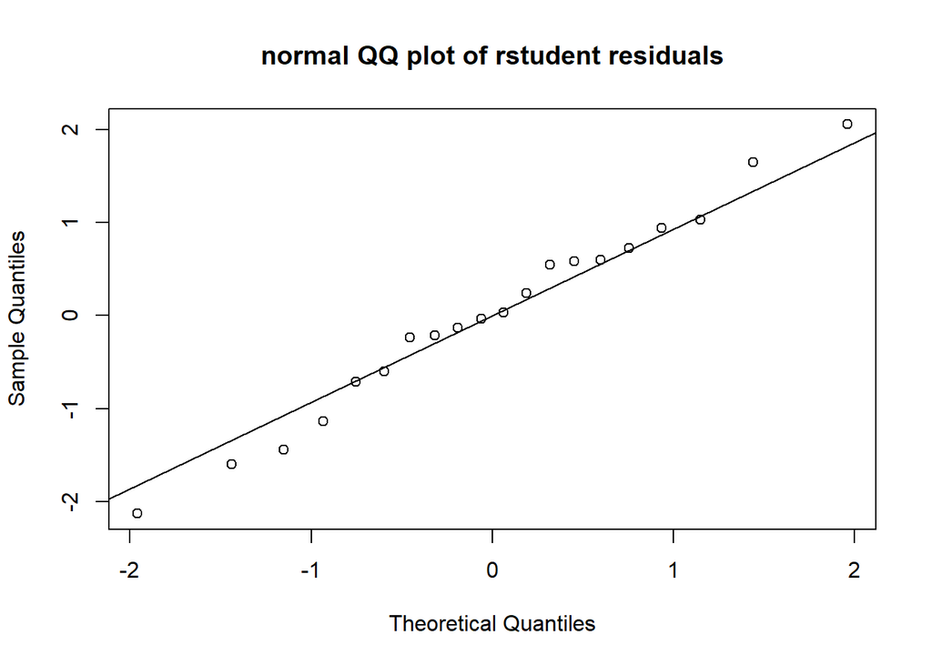

```r
#Assess normality of the observations as a whole using the r-student residuals.
qqnorm(rstudent(model.81),main="normal QQ plot of rstudent residuals")
qqline(rstudent(model.81))
```

No issues with the normal probability plot. Constant variance with the fitted values and regression variables versus residuals; the seems to be no issues with the model fits.

## Example 8.2 (p. 267-268)

#### Fit a model were ToolType is expected to influence both slope and intercept; compare the two models using the Partial F-test

#### Add column to dataframe for Interaction

```r
x_12 <- x_1 * x_2
Ex81$x_12 <- x_12

Ex81$x_12 <- c(x_12)

# Output data to make sure it reads properly
out <- as.data.frame(c(Ex81))
colnames(out) <- c("Obs",
                 "y_i",
                 "x_1",
                 "Tool_Type",
                 "x_2",
                 "x_12")
tab <- (xtable(out, digits=c(0,0,2,0,0,0,0)))
print(tab, type="html")
```

|  | Obs | y_i | x_1 | Tool_Type | x_2 | x_12 |
| --- | --- | --- | --- | --- | --- | --- |
| 1 | 1 | 18.73 | 610 | A | 1 | 610 |
| 2 | 2 | 14.52 | 950 | A | 1 | 950 |
| 3 | 3 | 17.43 | 720 | A | 1 | 720 |
| 4 | 4 | 14.54 | 840 | A | 1 | 840 |
| 5 | 5 | 13.44 | 980 | A | 1 | 980 |
| 6 | 6 | 24.39 | 530 | A | 1 | 530 |
| 7 | 7 | 13.34 | 680 | A | 1 | 680 |
| 8 | 8 | 22.71 | 540 | A | 1 | 540 |
| 9 | 9 | 12.68 | 890 | A | 1 | 890 |
| 10 | 10 | 19.32 | 730 | A | 1 | 730 |
| 11 | 11 | 30.16 | 670 | B | 0 | 0 |
| 12 | 12 | 27.09 | 770 | B | 0 | 0 |
| 13 | 13 | 25.40 | 880 | B | 0 | 0 |
| 14 | 14 | 26.05 | 1000 | B | 0 | 0 |
| 15 | 15 | 33.49 | 760 | B | 0 | 0 |
| 16 | 16 | 35.62 | 590 | B | 0 | 0 |
| 17 | 17 | 26.07 | 910 | B | 0 | 0 |
| 18 | 18 | 36.78 | 650 | B | 0 | 0 |
| 19 | 19 | 34.95 | 810 | B | 0 | 0 |
| 20 | 20 | 43.67 | 500 | B | 0 | 0 |

#### Create full model; compare to p. 267

```r
model.82 <- lm(y_i ~ x_1 + x_2 + x_12)

summary(model.82)
```

```
##
## Call:
## lm(formula = y_i ~ x_1 + x_2 + x_12)
##
## Residuals:
##     Min      1Q  Median      3Q     Max
## -5.1750 -1.4999  0.4849  1.7830  4.8652
##
## Coefficients:
##               Estimate Std. Error t value Pr(>|t|)
## (Intercept)  56.745353   4.934565  11.500  3.8e-09 ***
## x_1          -0.032914   0.006425  -5.123 0.000102 ***
## x_2         -23.970593   6.768973  -3.541 0.002716 **
## x_12          0.011944   0.008842   1.351 0.195533
## ---
## Signif. codes:  0 '***' 0.001 '**' 0.01 '*' 0.05 '.' 0.1 ' ' 1
##
## Residual standard error: 2.968 on 16 degrees of freedom
## Multiple R-squared:  0.9105, Adjusted R-squared:  0.8937
## F-statistic: 54.25 on 3 and 16 DF,  p-value: 1.319e-08
```

The least squares fit equation is:
$$\hat{y}= 56.7453533 +
(-0.0329143)x_1 +
(-23.9705934)x_2 +
(0.011944)x_1x_2$$

$$R^2 = 0.9104965$$
$$R^2_{adj} = 0.8937147$$
$$F_0 = 54.2546849$$

#### Calculate SS and df for Regression and Residual for full model; compare to Table 8.3, p. 268

```r
x <- anova(model.82)

SS_Reg <- sum(x$`Sum Sq`[1:3])
df_Reg <- sum(x$Df[1:3])

SS_Res <- x$`Sum Sq`[4]
df_Res <- x$Df[4]
```

Sum of Squares (SS) Regression: $1434.1123507$ and Degrees of Freedom (df) Regression: $3$

Sum of Squares (SS) Residual: $140.9758293$ and Degrees of Freedom (df) Residual: $16$

#### Test significance of interaction term using Partial F-test. Use alpha = 0.05 as the significance level; compare to values on p. 268

```r
# full model including interaction term
model.full <- lm(y_i ~ x_1 + x_2 + x_12)

# reduced model excluding interaction term
model.reduced <- lm(y_i ~ x_1 + x_2)

# anova -- comparision of reduced to full model
anova(model.reduced, model.full)
```

|  | Res.Df | RSS | Df | Sum of Sq | F | Pr(>F) |
| --- | --- | --- | --- | --- | --- | --- |
| 1 | 17 | 157.0546 | NA | NA | NA | NA |
| 2 | 16 | 140.9758 | 1 | 16.07873 | 1.82485 | 0.195533 |

```r
# F crit
alpha <- 0.05
df_SS_R <- anova(model.reduced, model.full)$'Df'[2]
df_SS_Res <- anova(model.reduced, model.full)$'Res.Df'[2]

F_crit <- qf(1-alpha,df_SS_R,df_SS_Res)

F_0 <- anova(model.reduced, model.full)$'F'[2]
p_value <-  anova(model.reduced, model.full)$'Pr(>F)'[2]
```

The appropriate hypotheses are
$$H_0:\beta_3=0, H_1:\beta_3 \ne 0$$

To test
$$H_0:\beta_3=0$$
form the test statistic
$$F_0 = \frac{SS_{reg}(\beta_3|\beta_2,\beta_1,\beta_0)/1}{MS_{Res}} = \frac{16.0787331}{8.8109893}=1.8248499$$
and since $F_{0.05,1,16} = 4.4939985$, we have $F_0 \lt F_{0.05,1,16}$ and a p-value of $P = 0.195533$ which is greater than the $0.05$ threshold. We don’t reject the null hypothesis and conclude that the interaction term is not significant.

#### Test hypothesis that the regression lines for each tool type are identical; compare to p. 268.

```r
# full model including interaction term
model.full <- lm(y_i ~ x_1 + x_2 + x_12)

# reduced model excluding interaction term
model.reduced <- lm(y_i ~ x_1)

# anova -- comparision of reduced to full model
anova(model.reduced, model.full)
```

|  | Res.Df | RSS | Df | Sum of Sq | F | Pr(>F) |
| --- | --- | --- | --- | --- | --- | --- |
| 1 | 18 | 1282.0828 | NA | NA | NA | NA |
| 2 | 16 | 140.9758 | 2 | 1141.107 | 64.75476 | 2.137119e-08 |

```r
# F crit
alpha <- 0.05
df_SS_R <- anova(model.reduced, model.full)$'Df'[2]
df_SS_Res <- anova(model.reduced, model.full)$'Res.Df'[2]

F_crit <- qf(1-alpha,df_SS_R,df_SS_Res)
```

To test the hypothesis that the two regression lines are identical,
$$H_0: \beta_2=\beta_3=0$$
use the statistic
$$F_0 = \frac{SS_R(\beta_2,\beta_3|\beta_{1},\beta_{0}/2}{MS_{Res}}=\frac{1141.1069474/2}{8.8109893}=64.7547571$$
and since $F_{0.05,2,16} = 3.6337235$, we have $F_0 \gt F_{0.05,2,16}$ and also the P statistic is $P=2.1371192\times 10^{-8}$. We reject the null hypothesis and conclude that the two regression lines are not identical.